# Team Name Analysis

Brian Waismeyer

October 20, 2015

This is an analysis of Team 7’s “Team Name and Logo” survey data. These data were collected in a highly scientific manner and can be considered an exact reading of the team’s feelings towards different candidate names and towards Amanda’s logo skillz.

## Load Libraries and Data

First off, we need to load the most powerful R packages possible - the scale and importance of the data is nearly beyond comprehension.

```r
# load crazy-powerful packages
library(dplyr)
library(tidyr)
library(stringr)
library(ggplot2)
```

Then we need to lovingly, cautiously, and tremendously load the data.

```r
# load the data, assuming that data is in the current working directory
team_df <- read.csv("Score the team names! (Responses) - Form Responses 1.csv",
                    stringsAsFactors = FALSE)
# ignoring the stupid formatting warning, we inspect the results
str(team_df)
```

```
## 'data.frame':    4 obs. of  17 variables:
##  $ Timestamp                                                          : chr  "10/20/2015 12:59:21" "10/20/2015 13:06:55" "10/20/2015 13:37:30" "10/20/2015 14:28:20"
##  $ Team.Hello.Kitty                                                   : int  5 3 3 6
##  $ Volatile.Data.Warehouse..VDW.                                      : int  5 5 5 6
##  $ BFS..Bibin.Forgot.the.Spandex.                                     : int  5 7 4 1
##  $ Volatile.Spandex.Latinas                                           : int  5 4 4 1
##  $ Against.the.Grain..of.the.Data.                                    : int  6 5 7 1
##  $ Normally.DeNormalized                                              : int  7 5 7 4
##  $ Dancing.with.the.Star.Schemas                                      : int  4 5 7 5
##  $ OLAP.Dancers                                                       : int  6 4 5 5
##  $ Cubes.on.a.Snowflake                                               : int  4 3 7 4
##  $ DW.from.UW                                                         : int  4 4 7 5
##  $ ETL.Tools                                                          : int  3 4 7 5
##  $ Extract.Enjoy.Eat.the.Spandex..EEETS.                              : int  3 4 3 3
##  $ Repressed.Spandex                                                  : int  5 4 4 3
##  $ Big.Cloudy.Data                                                    : int  7 4 7 4
##  $ Feel.free.to.add.any.additional.team.names.you.wish.us.to.consider.: chr  "" "I peed myself laughing" "I'm not sure if Sean is the kind of guy who takes jokes jovially :| Remember when Dustin did a woohoo on the guest lecturer and"| __truncated__ ""
##  $ Should.Amanda.be.in.charge.of.the.team.logo.                       : chr  "Mwahahahahahahaha!" "Mwahahahahahahaha!" "SHE SHOULD BE IN CHARGE OF EVERYTHING" "SHE SHOULD BE IN CHARGE OF EVERYTHING"
```

## Carpenter the Data

The data arrives in a format as wide as yo mama and with more awkward periods. With calm strokes and sturdy hands, we craft the data to be lean and mean and clean.

```r
# rename the last two variables to be less crazy
names(team_df)[16:17] <- c("notes", "Amanda_logo")

# grab the data by the hand
clean_df <- team_df %>%
    # drop notes and timestamp because we don't care
    select(-notes, -Timestamp) %>%
    # add a person id 'cuz it's easier to deal with than the timestamps
    mutate(person_id = row_number()) %>%
    # flip the data from wide as #### to long
    gather("team_name", "rating", -person_id, -Amanda_logo)

# clean up all those cray-cray periods
clean_df$team_name <- str_replace_all(clean_df$team_name, "[.]", " ")

# replace double spaces with sweet, sweet space-dash-space
clean_df$team_name <- str_replace_all(clean_df$team_name, "[ ][ ]", " - ")

# ADMIRE OUR WORK
tbl_df(clean_df)
```

```
## Source: local data frame [56 x 4]
##
##                              Amanda_logo person_id
##                                    (chr)     (int)
## 1                     Mwahahahahahahaha!         1
## 2                     Mwahahahahahahaha!         2
## 3  SHE SHOULD BE IN CHARGE OF EVERYTHING         3
## 4  SHE SHOULD BE IN CHARGE OF EVERYTHING         4
## 5                     Mwahahahahahahaha!         1
## 6                     Mwahahahahahahaha!         2
## 7  SHE SHOULD BE IN CHARGE OF EVERYTHING         3
## 8  SHE SHOULD BE IN CHARGE OF EVERYTHING         4
## 9                     Mwahahahahahahaha!         1
## 10                    Mwahahahahahahaha!         2
## ..                                   ...       ...
## Variables not shown: team_name (chr), rating (int)
```

## Stare Deep into the Data’s Eyes

We have carved ourselves a unicorn. Let’s pet that unicorn and see what wishes it grants us.

First we check out our thoughts on team names.

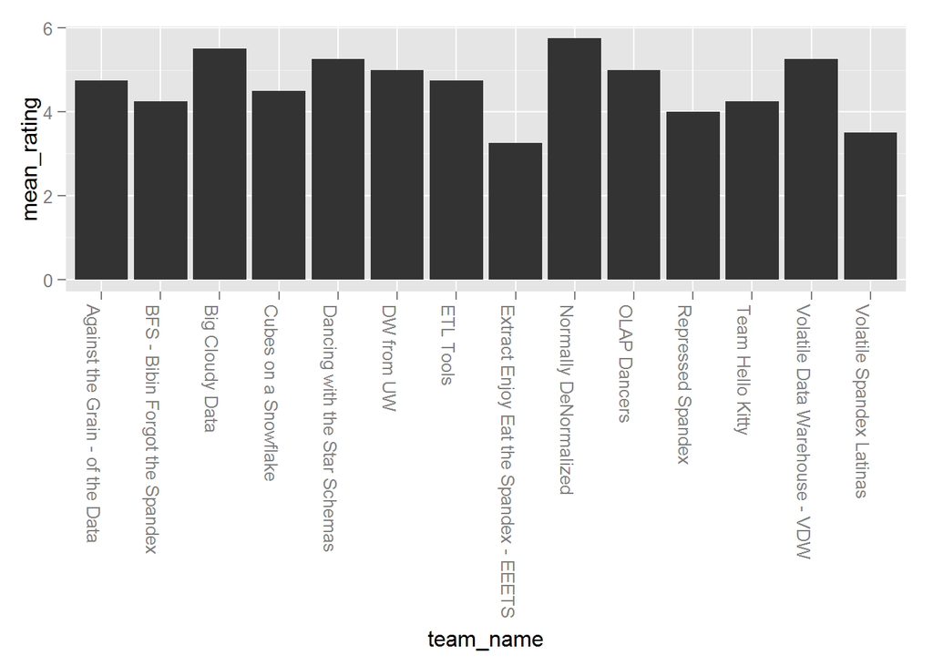

```
## Source: local data frame [14 x 3]
##
##                                 team_name mean_rating sd_rating
##                                     (chr)       (dbl)     (dbl)
## 1                   Normally DeNormalized        5.75 1.5000000
## 2                         Big Cloudy Data        5.50 1.7320508
## 3           Dancing with the Star Schemas        5.25 1.2583057
## 4          Volatile Data Warehouse - VDW         5.25 0.5000000
## 5                              DW from UW        5.00 1.4142136
## 6                            OLAP Dancers        5.00 0.8164966
## 7        Against the Grain - of the Data         4.75 2.6299556
## 8                               ETL Tools        4.75 1.7078251
## 9                    Cubes on a Snowflake        4.50 1.7320508
## 10        BFS - Bibin Forgot the Spandex         4.25 2.5000000
## 11                       Team Hello Kitty        4.25 1.5000000
## 12                      Repressed Spandex        4.00 0.8164966
## 13               Volatile Spandex Latinas        3.50 1.7320508
## 14 Extract Enjoy Eat the Spandex - EEETS         3.25 0.5000000
```

```r
# get the mean/sd for each team name rating and rank the names by sexy
clean_df %>%
    group_by(team_name) %>%
    summarise(mean_rating = mean(rating),
              sd_rating = sd(rating)) %>%
    arrange(desc(mean_rating),
            desc(sd_rating))

# slap it into a graph BECAUSE WE CAN
clean_df %>%
    group_by(team_name) %>%
    summarise(mean_rating = mean(rating),
              sd_rating = sd(rating)) %>%
    ggplot(aes(x = team_name, y = mean_rating)) +
        geom_bar(stat = "identity") +
        theme(axis.text.x=element_text(angle = -90, hjust = 0))
```

Those are some sexy thoughts for some sexy team names.

Next we assess Amanda’s logo skilllllllzzz.

```r
# table it
clean_df %>%
    group_by(Amanda_logo, person_id) %>%
    summarise() %>%
    summarise(answer_count = n()) %>%
    ungroup() %>%
    mutate(answer_prop = answer_count / sum(answer_count))

# we don't need  no graph to see what we need to see
```

```
## Source: local data frame [2 x 3]
##
##                             Amanda_logo answer_count answer_prop
##                                   (chr)        (int)       (dbl)
## 1                    Mwahahahahahahaha!            2         0.5
## 2 SHE SHOULD BE IN CHARGE OF EVERYTHING            2         0.5
```

Mmm. It seems that Evil Amanda should be in charge of everything.

Finally, we grapple with Amanda’s demand for a scatterplot by plotting the weirdest things that come to mind.

```
## geom_smooth: method="auto" and size of largest group is <1000, so using loess. Use 'method = x' to change the smoothing method.
```

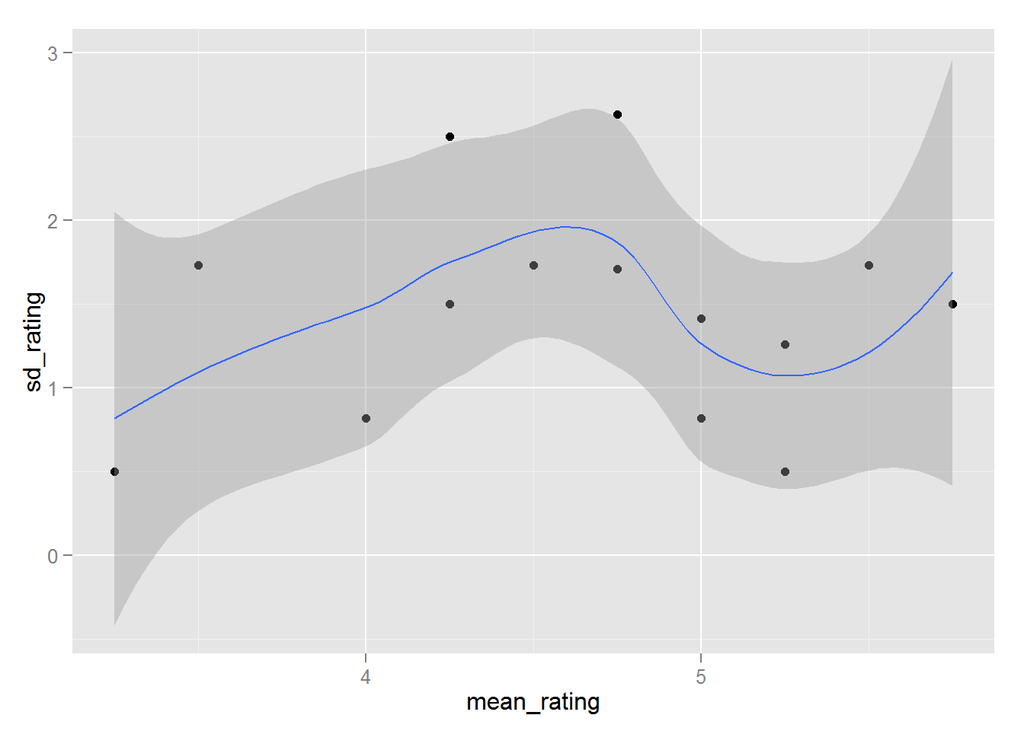

```r
# first we plot mean rating against sd rating to see how variability changes
# as mean ratings approach different regions of the rating range...
# that's probably the smartest thing I've written in this whole report...
# I'm gonna smugly congratulate myself for this all day...
clean_df %>%
    group_by(team_name) %>%
    summarise(mean_rating = mean(rating),
              sd_rating = sd(rating)) %>%
    ggplot(aes(x = mean_rating, y = sd_rating)) +
        geom_point() +
        # we slap on a smoother to make it look like cool stuff is happening
        geom_smooth()
```

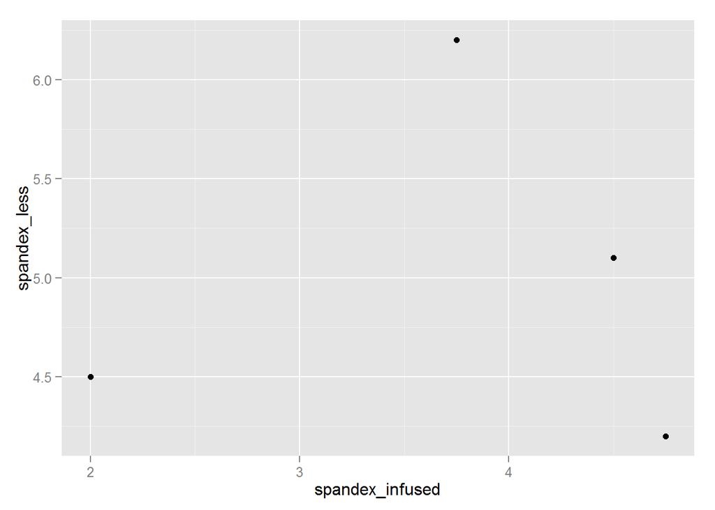

```r
# next we assess if people who rate spandex names low rate everything low,
# implying that spandex-repressed people are h8ters
clean_df %>%
    # need a column to distinguish types of team name
    mutate(spandex_name = ifelse(grepl("Spandex", team_name),
                                 "spandex_infused", "spandex_less")) %>%
    # get each persons mean rating for spandex and non-spandex titles
    group_by(person_id, spandex_name) %>%
    summarise(mean_rating = mean(rating)) %>%
    # spread the dataframe so that we can make points
    spread(spandex_name, mean_rating) %>%
    # make us a PLOT
    ggplot(aes(x = spandex_infused, y = spandex_less)) +
        geom_point()
```

We learn that our group is pretty small to make scatterplots and Bibin is totally a negative-spandex-Nancy.